# Data visualization: perspectives

Rob Davies

## We are learning how to think critically for ourselves

*Active learning* works best even if it sometimes feel challenging

- Active learning is what you do when you ask or answer questions
- We will prompt you sometimes with Activate

**Activate**

Can you think of a visualization that *really* affected you?

## Introduction: Data visualization – perspectives

- In this lecture, we focus on *perspectives* or how we can think about visualization
- In the linked lecture, we look at *practices* or how we get visualization done

## What we are going to do

1. Recent history – a selective sketch
2. Important case studies – a discussion
3. Identify your goals – a tool kit
4. Think about your audience – a tool kit

## Our learning objectives: *Concepts* — what are we learning about?

We are working together to help you:

1. *Importance* — Understand why visualization is important to you
2. *Context* — Understand the historical context for how we think about visualization now
3. *Goals* — Formulate questions you can ask yourself to help you to work effectively
4. *Audience* — Understand the psychological factors that affect your impact

## Our assessment targets: *Concepts* — how do you know if you have learned?

We are working together so you can:

1. *Importance* — Communicate why it is worth investing in visualization
2. *Context* — Build a scholarly appreciation for the roots of visualization ideas and practices
3. *Goals* — Identify a set of targets for a development process in your professional teams
4. *Audience* — Understand what you need to do to make a visualization effective for your audience

## Recent history – A reminder of why data visualization matters

**Tip**

- I am going to talk, next, about COVID-19 and the deaths associated with the pandemic
- I am also going to talk about vaccines and climate change

## Data visualization changes policy

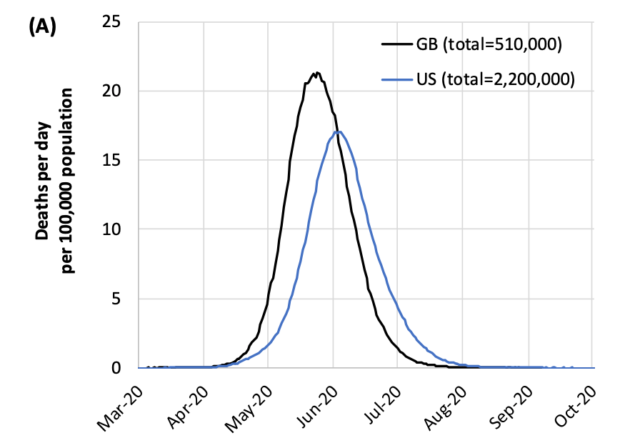

Ferguson et al. (2020; 16 March) Unmitigated epidemic scenarios for GB and the US. Projected deaths per day per 100,000 population in GB and US. … *seeing* projected deaths led to policy change

## Data visualization: Why we care

- In some reporting, when UK leaders saw that predicted total deaths could reach 500,000 lives in Britain
- Policy changed from mitigation to lock-down (in mid-March)

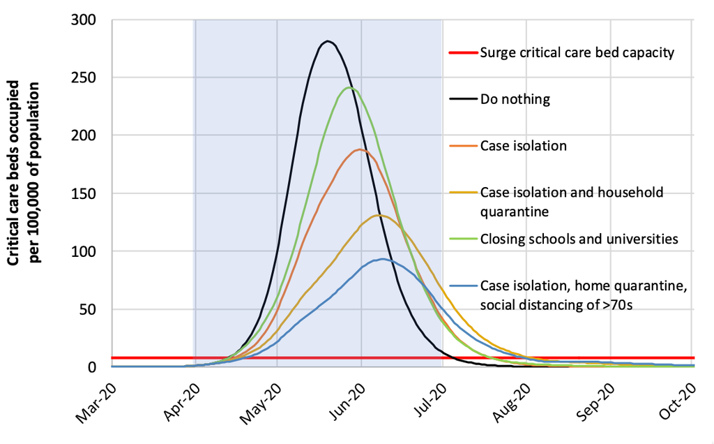

Ferguson et al. (2020; 16 March) Mitigation strategy scenarios for GB showing critical care (ICU) bed requirements

## Visualizations can show average results *and* reveal uncertainty

- Among those with previous SARS-CoV-2 infection, vaccination increased immune response more than 140 times compared to peak pre-vaccine levels (Manisty et al., 2021)
- Plot shows average outcomes (black lines) and individual outcomes (points)

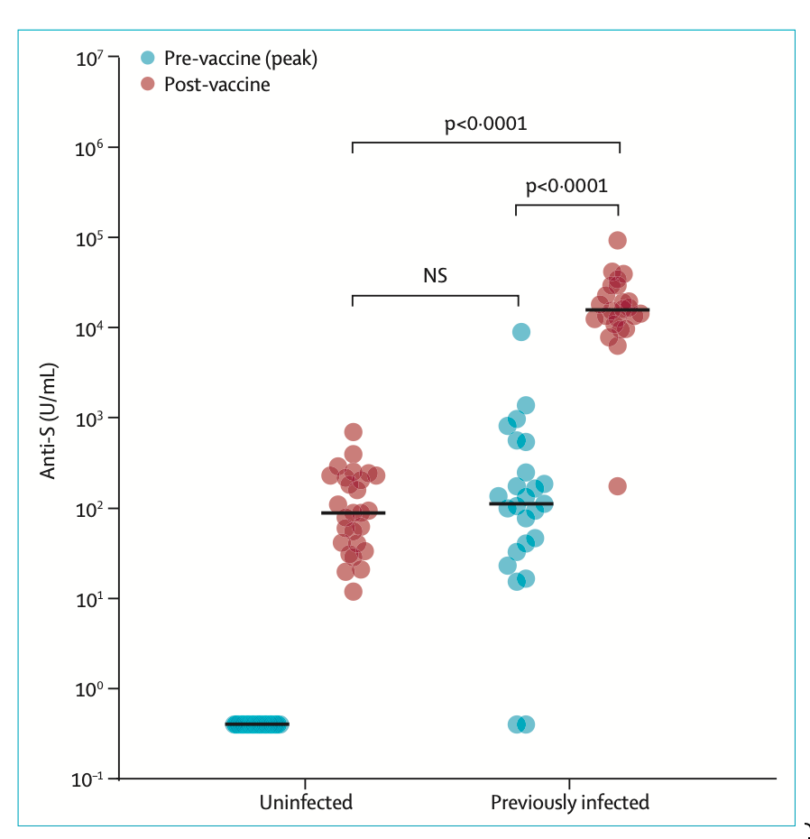

Manisty et al (2021) Response to one dose of COVID-19 vaccine in individuals with and without previous infection

## Modern visualization enables effective communication

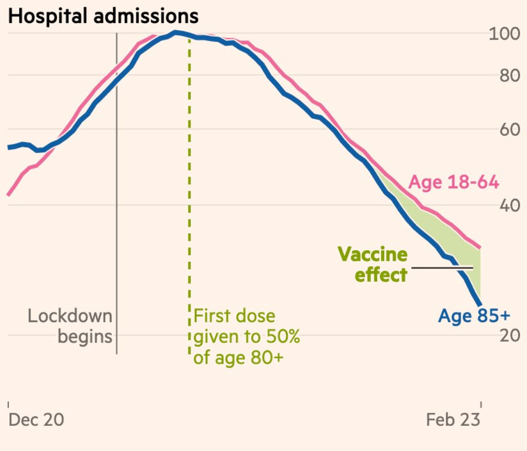

John Burn-Murdoch, Financial Times, 2021, Twitter

## Battling infectious diseases in the 20th Century: vaccinations

- Heat maps show the decline in cases: Measles
- per 100,000 people, after the introduction of vaccinations (DeBold & Friedman, Dov, n.d.)

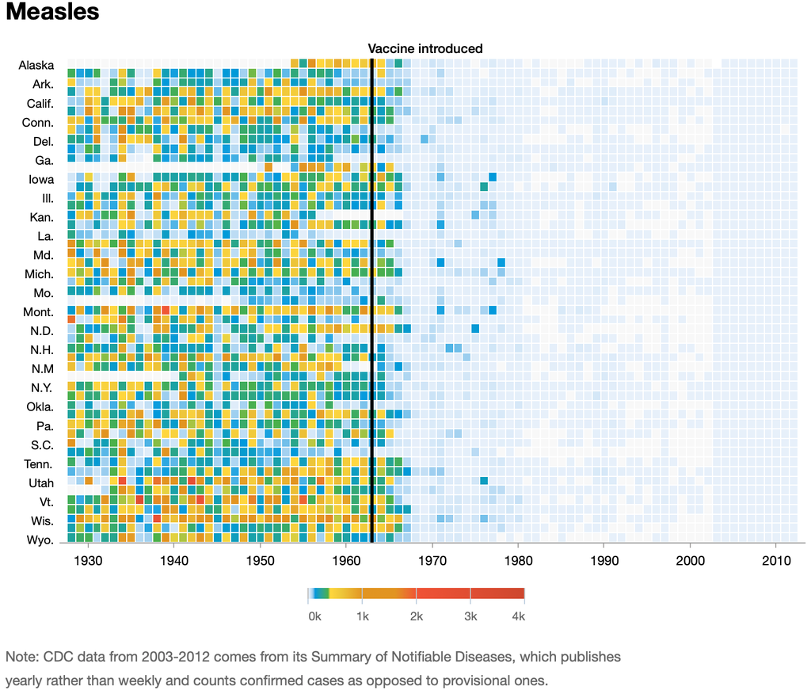

DeBold and Friedman (2024). Battling infectious diseases in the 20th Century Wall Street Journal

## Battling infectious diseases in the 20th Century: vaccinations

- Since 1974, vaccination has averted 154 million deaths (Shattock et al., 2024)
- also: years of life gained, years of full health gained

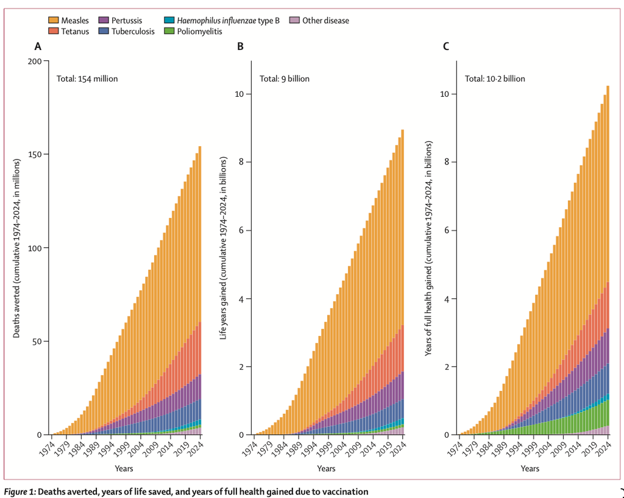

Shattock et al. (2024). Contribution of vaccination to improved survival and health

## Climate change: Show your stripes

[figure not shown]

Ed Hawkins `https://showyourstripes.info`

## Climate change: UK coal phase out

- How the UK displaced coal power from its electricity supply
- The impact of policy

[figure not shown]

Mayo (2024). `https://ember-energy.org/latest-insights/the-uks-journey-to-a-coal-power-phase-out`

## Climate change: presistent pessimism

- The energy transition will be much cheaper than you think
- The difference between forecast and actual capacity over time

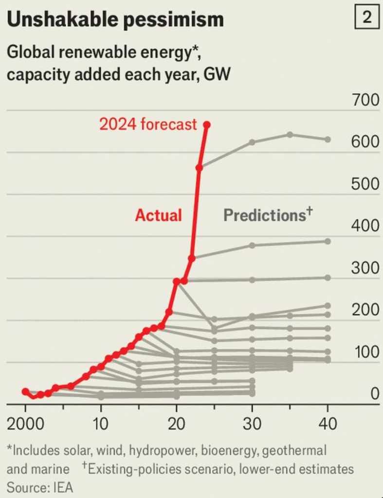

Economist (2024). `https://www.economist.com/interactive/briefing/2024/11/14/the-energy-transition-will-be-much-cheaper-than-you-think`

## Lessons from recent history

1. *One key message* — Model-based predictions (Imperial); Show your stripes (Hawkins, Reading)
2. *Show the average, show the data* — Reveal the uncertainty behind the results (Manisty)
3. *Enable comparisons* — Comparisons over time (DeBold & Friedman, Dov, n.d.; Shattock et al., 2024)
4. *Direct attention* — Use colour, scaling, and annotation to direct your audience to your message (Burn-Murdoch, 2021 FT; Economist, 2024; Mayo, 2024 EMBER)

## Activate

Questions to reflect on:

**Activate**

- Do you recognize these visualizations (or visualizations like them)?
- Why? What makes them memorable or striking to you now?

## Important case studies – What they teach us

**Tip**

- I am going to change focus now
- To look at the history of visualization

## The Minard plot

[figure not shown]

This famous visualization by Charles Minard shows the number of French soldiers (width of line) marched to Russia (brown towards Moscow) and back (black line) by Napoleon in 1812-13

## The Snow map

- John Snow’s map uses small bar graphs on city blocks to mark the number of cholera deaths at each household in a London neighbourhood
- It shows that households that suffered the most from cholera were all using the same well for drinking water

[figure not shown]

John Snow’s 1854 Broad Street Cholera Outbreak Map

## Doll and Bradford Hill

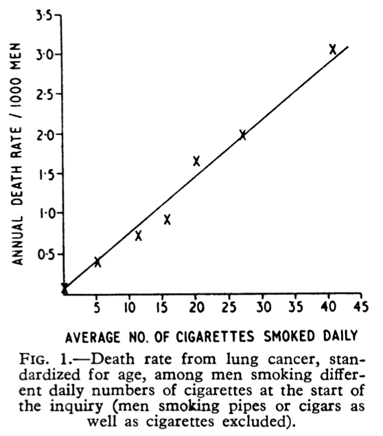

Doll & Hill (1964): The mortality rate increases step by step with increasing number of cigarettes smoked daily

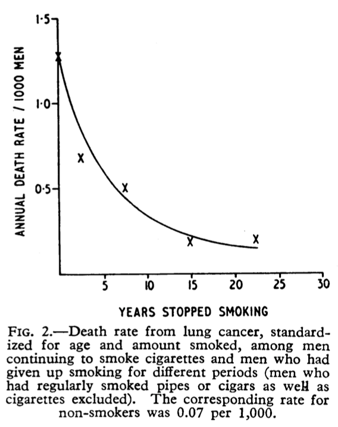

Mortality rates for lung cancer and other diseases decline after smoking cessation

## Isotype: a pictorial language system

- Pioneering Austrian sociologist Otto Neurath and Marie Reidemeister (later Marie Neurath)
- invented *ISOTYPE*: a language-like system of pictograms

> To remember simplified pictures is better than to forget accurate figures

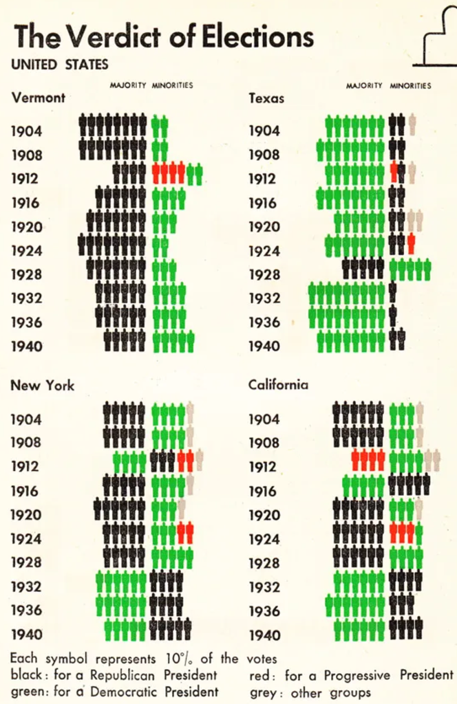

Maria Popova | www.themarginalian.org

## WEB Du Bois: using visualization to contextualize historical realities

- W.E.B. Du Bois, the prominent African-American intellectual
- sought a way to process all the information showing why the African disapora in America was being held back
- In doing so, he helped to invent Sociology and infographics

[figure not shown]

Britt Rusert Whitney Battle-Baptiste “W.E.B. Du Bois’s Data Portraits Visualizing Black America”

## John Tukey: Exloratory Data Analysis

- Professional researchers develop awareness of what surprises
- John Tukey said:

> The greatest value of a picture is when it forces us to notice what we never expected to see

[figure not shown]

Source: https://alchetron.com/John-Tukey

## People invent visualizations: Mary Eleanor Spears

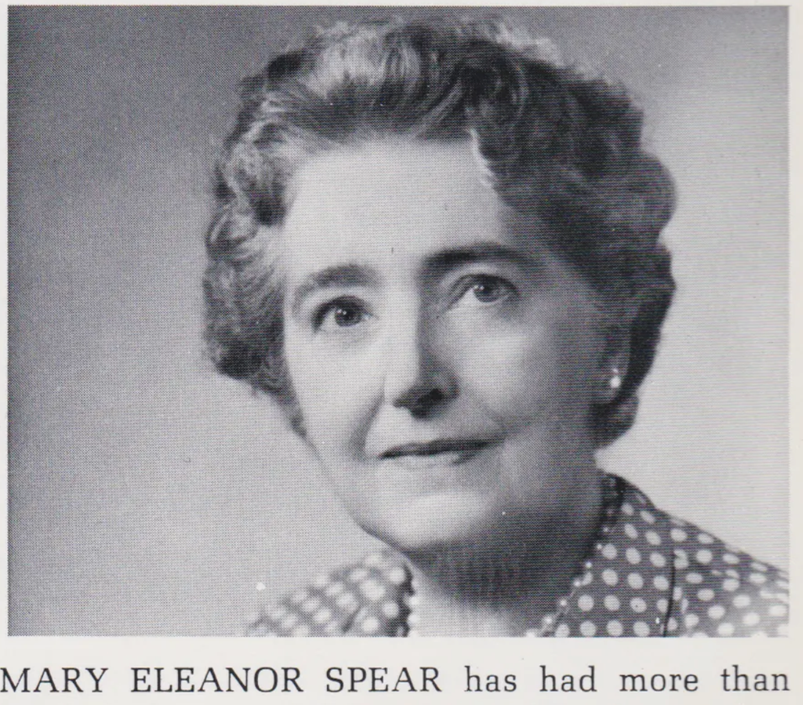

Ben Jones | medium.com — Mary Eleanor Spear: Inventor of the box plot in the 1950s

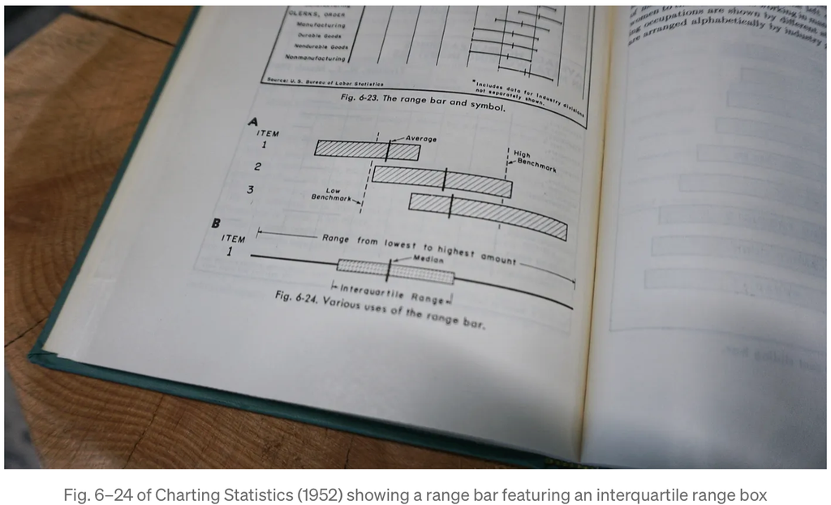

Ben Jones | medium.com — image of range bar — an early version of the *box plot* in the 1952 book “Charting Statistic”

## What history teaches us

1. *Show the story* — the Minard plot creates a dynamic narrative about losses over time and space
2. *Making sense of evidence* — the Snow map shows how we can use graphic presentations to reason
3. *Show the average, show the data* — the Doll and Hill plots communication conclusions immediately
4. *Enable comparisons* — the Neurath Isotype chart enables easy comparisons between times and places
5. *Stimulate attention* — the Du Bois chart draws the attention of the viewer through artistry, use of shape and colour

## What are our goals – Questions to reflect on

**Activate**

These lessons from history show what is possible: *What can you do?*

- Next, we ask you to reflect on the question: *What should you do?*

## What are our goals – Questions to reflect on

**Tip**

Why bother? What investment in time or energy is worthwhile?

- Why don’t we just use the *good enough* easy to produce plots in Excel? $\rightarrow$ *Why bother?*
- Why don’t we just produce a summary table? $\rightarrow$ *Why bother?*
- Are we engaged in making beautiful graphics or informative displays or both? $\rightarrow$ *What are we doing?*
- In the linked *Practices* lecture, we look at $\rightarrow$ *How we get it done*

## What are our goals – Questions to reflect on

**Tip**

What is our job to do?

- *Data visualization* workers may aim to get and keep the attention of an audience, to tell a story, to persuade viewers
- *Data analysis* workers may aim to enable your audience to understand your data, your findings, and to discover more

## What are our goals – Questions to reflect on

**Tip**

Where or when are we in our process?

- Sometimes in a *workflow*, we are quickly sketching draft visualizations: exploring, for ourselves, or with others, what we can see in our data
- Sometimes, we are ready to present our visualization to a wider audience: we share a polished visual object

## What are our goals? – Questions to reflect on

**Tip**

Who is our audience?

- In visualizing data for scientific audiences, we may use *standard* forms (e.g., scatterplots)
- That rely on the experience of our readers
- We assume common knowledge of *conventions*
- When e.g. we draw scatterplots, we conventionally put explanatory variables on the (horizontal) x-axis and the outcome of interest on the (vertical) y-axis

## Why don’t we just use tables?

The datasaurus shows you can never depend on summary statistics alone

```
    Pearson's product-moment correlation

data:  datasaurus$A and datasaurus$B
t = -0.76443, df = 140, p-value = 0.4459
alternative hypothesis: true correlation is not equal to 0
95 percent confidence interval:
 -0.2267905  0.1013316
sample estimates:
        cor
-0.06447185
```

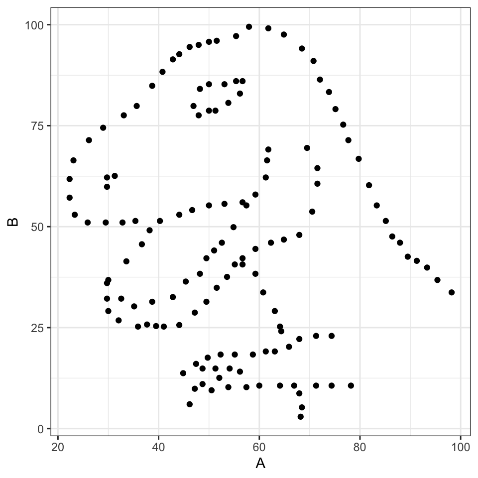

Figure 1: Alberto Cairo’s datasaurus: http://www.thefunctionalart.com

## Why don’t we just use tables?

- Statistical software (like R) will give us summary tables that we can present without much work: why don’t we just do tables?
1. Tables are good for looking up specific information but hard to use for comparisons or trends (Gelman et al., 2002; Kastellec & Leoni, 2007)
2. The ease of tables switches *our* brains off, making it easier to see less in *our own* results
3. We can communicate more effectively with *our audience* using good visualizations

## What are our goals: Discovery

**Tip**

*Discovery goals*

1. Do we need an overview? – To get a sense of what is in the data, and to check our assumptions
2. Are we looking for the unexpected? – Comparing groups to check for variability, exploring data open to surprises

## What are our goals: Communication

**Tip**

*Communication goals*

1. What do we need our audience to understand?
2. What story are we telling?
3. Do we need to attract attention or stimulate interest?

## Activate

Questions we can reflect on so that we can make decisions for ourselves:

**Activate**

- What are our goals: discovery or communication?
- Who is our audience?
- What is it our job to do?
- Where or when are we in the process?
- What investment is warranted?

## Think about your audience – An evidence based account of what works

**Tip**

- What works?
- We will produce more effective visualizations if we think about how our audience *sees*, and what they *expect*
- We build, here, mostly from a comprehensive review of evidence by Franconeri et al. (2021)
- Humans can process visual information *efficiently*
- Your audience will process some kinds of information *more precisely* than others — from higher precision to lower:
1. position
2. length
3. area
4. angle
5. intensity

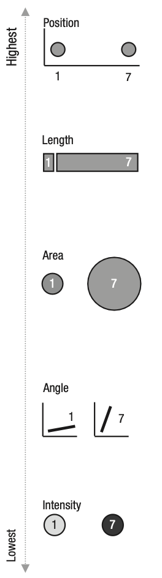

Franconeri et al. (2021) Fig. 2

- Your audience can look at your visualization
- And quickly and easily extract statistical information from what you show
- You look at a scatterplot and see the minimum, maximum and mean heights of the points

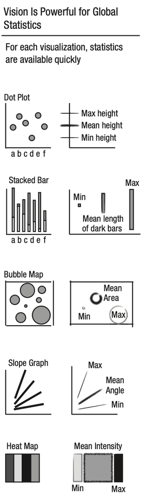

Franconeri et al. (2021) Fig. 2

- Many visualization designers advise drawing plots so that
- y-axis limits reflect the full range of possible data values

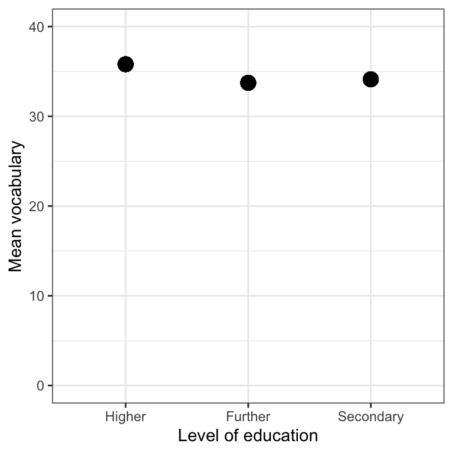

Figure 2: y-axis limits span the full range of Shipley vocabulary scores

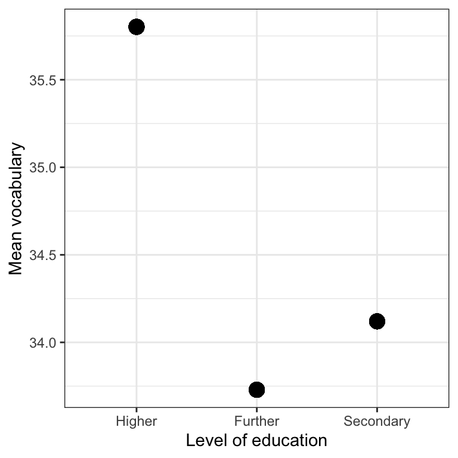

Figure 3: Limits focus on a narrow range: **amplifying** the apparent difference

- Comparisons can make your audience take time and effort
- Slowing their response to your visualization
- Sometimes this requires design adaptations: annotate; use position; use colour

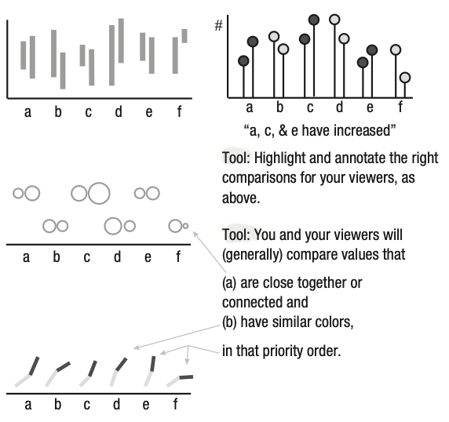

Franconeri et al. (2021) Fig.2

## Communicating uncertainty is critical

- As scientists, we need to think about uncertainty all the time
- We quantify and can show uncertainty over estimates e.g. of average outcomes or average differences
- But it is important that we do not forget to show or think about about outcome variability

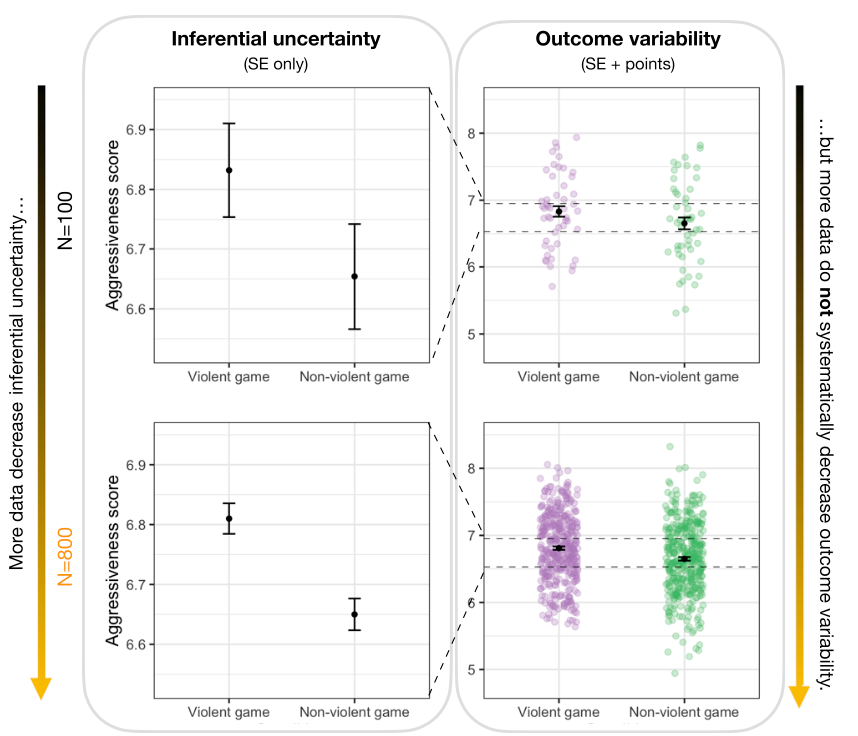

Zhang et al. (2023): The difference between uncertainty over estimates and uncertainty over the predictability of outcomes

## Think about your audience – Quick start

- Your visual system can extract broad statistics about data very quickly
- You can be fooled by common visual illusions and confusions
- Extracting global statistics is fast but comparisons are slow

## Think about your audience – Quick start

- Visual communication is challenging because there is a *Theory of Mind* problem
- New visualization formats must be learned so work with convention or explain the new thing
- When communicating uncertainty to a lay audience, show the data
- Support understanding in audiences with low literacy or numeracy or low background knowledge and use annotation to explain what your plot shows

## Think about accessibility from the start

- The first row shows a scatterplot encoded with two colors, green and orange
- People with typical vision can see that the green dots have a steep positive correlation and the orange dots make a flat line
- We use colour blindness friendly colour palettes

[figure not shown]

Franconeri et al. (2021) Fig.5

## Introduction: Data visualization – perspectives

Remember:

- In this lecture, we focused on *perspectives* or how we can think about visualization
- Go to the linked lecture, to look at *practices* or how we get visualization done

## End of *Data visualization – perspectives*

**Activate**

When you produce your visualization, ask yourselves these questions:

- What visualizations have affected me? Why?
- What are my goals?
- Who is my audience?
- What effort is warranted?

## References

DeBold, T., & Friedman, Dov. (n.d.). *Battling infectious diseases in the 20th century: The impact of vaccines*. Retrieved http://graphics.wsj.com/infectious-diseases-and-vaccines

Doll, R., & Hill, A. B. (1964). Mortality in relation to smoking: Ten years’ observations of british doctors. *British Medical Journal*, *1*(5395), 1399–1410. https://www.ncbi.nlm.nih.gov/pmc/articles/PMC1814562/

Franconeri, S. L., Padilla, L. M., Shah, P., Zacks, J. M., & Hullman, J. (2021). The science of visual data communication: What works. *Psychological Science in the Public Interest*, *22*(3), 110–161. https://doi.org/10.1177/15291006211051956

Gelman, A., Pasarica, C., & Dodhia, R. (2002). Let’s practice what we preach. *The American Statistician*, *56*(2), 121–130. https://doi.org/10.1198/000313002317572790

Kastellec, J. P., & Leoni, E. L. (2007). Using graphs instead of tables in political science. *Perspectives on Politics*, *5*(4), 755–771. https://doi.org/10.1017/S1537592707072209

Manisty, C., Otter, A. D., Treibel, T. A., McKnight, Á., Altmann, D. M., Brooks, T., Noursadeghi, M., Boyton, R. J., Semper, A., & Moon, J. C. (2021). Antibody response to first BNT162b2 dose in previously SARS-CoV-2-infected individuals. *Lancet (London, England)*, *397*(10279), 1057–1058. https://doi.org/10.1016/S0140-6736(21)00501-8

Shattock, A. J., Johnson, H. C., Sim, S. Y., Carter, A., Lambach, P., Hutubessy, R. C. W., Thompson, K. M., Badizadegan, K., Lambert, B., Ferrari, M. J., Jit, M., Fu, H., Silal, S. P., Hounsell, R. A., White, R. G., Mosser, J. F., Gaythorpe, K. A. M., Trotter, C. L., Lindstrand, A., … Bar-Zeev, N. (2024). Contribution of vaccination to improved survival and health: Modelling 50 years of the expanded programme on immunization. *The Lancet*, *403*(10441), 2307–2316. https://doi.org/10.1016/S0140-6736(24)00850-X

Zhang, S., Heck, P. R., Meyer, M. N., Chabris, C. F., Goldstein, D. G., & Hofman, J. M. (2023). An illusion of predictability in scientific results: Even experts confuse inferential uncertainty and outcome variability. *Proceedings of the National Academy of Sciences*, *120*(33), e2302491120. https://doi.org/10.1073/pnas.2302491120